# Assignment 5 (class)

## (100 points)

**(Instruction)** The purpose of this assignment is to practice creating Class objects to improve the structure and readibility of your code.

Due date: March 28th, 2019, 10:30 am. Points will be taken off for later homework according to 10% per day.

# Question #1

We discussed the following codes in class to read a list of seismograms using class objects. In this problem, you will need to add more functions to the `seismogram` class.

```python
#define a class object name seismogram
class seismogram:
#the initial function will read the seismic data and save important information to attributes
    def __init__(self,filename):
        self.filename=filename
        fp=open(self.filename,"r")
        lines=fp.readlines()
        fp.close()
        temp=lines[0].split()
        self.freq=float(temp[0])
        f=float(temp[0])
        temp=lines[6].split()
        self.lat=float(temp[1])
        self.lon=float(temp[2])
        temp=lines[10].split()
        self.distance=float(temp[3])
        temp=lines[14].split()
        self.year=int(temp[0])
        self.day=int(temp[1])
        self.starttime=int(temp[2])*3600+int(temp[3])*60+int(temp[4])
        temp=lines[22].split()
        self.staname=temp[0]
        data=[]
        t=[]
        j=0
        for line in lines[30:]:
            temp=line.split()
            for i in temp:
                data.append(float(i))
                t.append(j)
                j=j+f
        self.data=np.array(data)
        self.t=np.array(t)

#add your function here.
```

```python
%matplotlib inline
import numpy as np
import matplotlib.pyplot as plt
import glob
files=glob.glob("./earthquakes/*")
#read all data
sta=[]
for f in files:
    s=seismogram(f)
    sta.append(s)
```

(a) Write a function named 'max_amp' in the 'seismogram' class to calculate the maximum amplitude of each seismogram. Output the results by [Distance_from_earthquake,maximum_amplitude]. Note that the distance of defined in self.distance (30 points)

```
[[7.546490e+01 1.512200e+04]
 [1.207173e+02 2.939000e+03]
 [1.006284e+02 3.683000e+03]
 [1.109680e+02 4.730500e+04]
 [1.508721e+02 6.587000e+03]
 [4.536378e+01 8.870000e+03]
 [1.366862e+02 7.703800e+04]
 [7.222691e+01 7.514880e+05]
 [1.563880e+02 2.450300e+04]
 [9.580891e+01 2.698000e+03]
 [5.025451e+01 2.144000e+04]
 [3.056567e+01 1.736400e+04]
 [6.558928e+01 1.211900e+04]
 [1.331622e+02 2.122910e+05]
 [2.173306e+01 1.179370e+05]
 [1.062663e+02 1.185100e+04]
 [1.508721e+02 3.348000e+03]
 [1.109680e+02 4.393500e+04]
 [1.464079e+02 1.814700e+04]
 [6.558928e+01 1.523700e+04]
 [1.413270e+02 5.415000e+03]
 [1.253471e+02 1.014900e+04]
 [1.155459e+02 7.500200e+04]
 [1.331622e+02 6.165000e+03]
 [4.042395e+01 4.440100e+04]
 [2.900372e+00 5.258978e+06]
 [1.253471e+02 5.301000e+03]
 [9.036618e+01 8.682000e+03]
 [6.176905e+01 5.625100e+04]
 [1.006284e+02 7.970000e+03]
 [2.900372e+00 6.768667e+06]
 [7.546490e+01 1.732400e+04]
 [1.580245e+01 3.847960e+05]
 [9.580891e+01 7.676660e+05]
 [8.167462e+01 2.196900e+04]
 [3.523321e+01 1.866600e+04]
 [1.366862e+02 3.483000e+03]
 [1.580245e+01 5.087050e+05]
 [1.155459e+02 1.014900e+04]
 [9.036618e+01 9.862000e+03]
 [1.253471e+02 1.154000e+03]
 [1.006284e+02 3.352000e+03]
 [4.536378e+01 1.084730e+06]
 [1.207173e+02 2.499000e+03]
 [1.062663e+02 7.265000e+03]
 [3.523321e+01 1.246300e+04]
 [1.006284e+02 3.292000e+03]
 [7.222691e+01 8.647000e+03]
 [6.176905e+01 3.636560e+05]
 [4.042395e+01 3.567000e+04]]
```

(b) plot the distance with maximum amplitude. Your figure should look the same as below: (10 points)

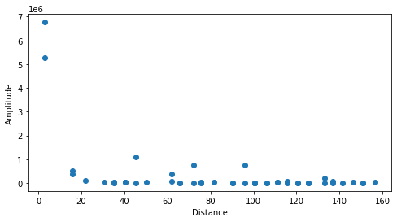

(c) add a function name 'splot' in the seismogram class to plot the seismogram with time on the x axis and amplitude on the y axis. Make a plot for the first seismogram at station 'LVZ'. You should get the following figure by running "sta[0].splot()" (20 points)

The following code needs to work after you modify the seismogram class.

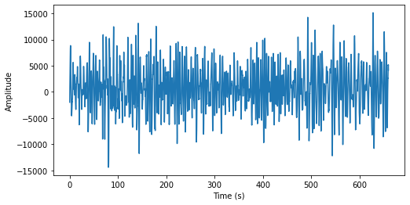

```python
sta[0].splot()
```

(d) Write a function to normalize the amplitude of each seismogram by the maximum amplitude. The following code needs to work correctly after you modify the seismogram class (20 points)

```python
for s in sta:
    s.max_amp()
    s.normalize()
```

(e) Make a plot for the first seismogram at station 'LVZ' after normalization. You should get the following figure by running "sta[0].splot()" (10 points)

The following code needs to work after you modify the seismogram class.

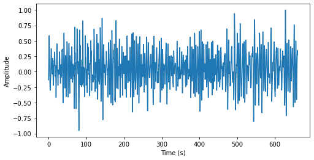

```python
sta[0].splot()
```

(e) (20 points)

- Write a function named 'resample' that takes one input as the sample rate to resample the time series data. For example, when I enter sta[0].resample(100), it will resample the first station data every 100 data points.
- plot the data for the first seismic station.

The following code needs to work after you modify the seismogram class.

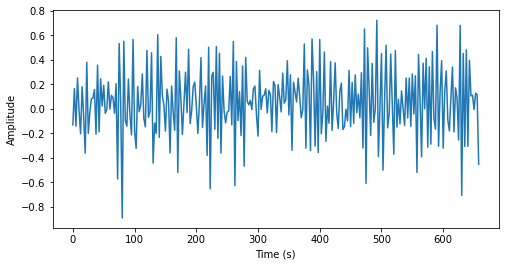

```python
sta[0].resample(100)
sta[0].splot()
```